# Lobster Report

Yulissa T. Perez Rojas and Michelle D. Mohr

2023-04-05

## Citation of Data

This data was obtained from [The EDI Data Portal](https://portal.edirepository.org/nis/mapbrowse?packageid=knb-lter-sbc.77.8)

## Abstract

Data on abundance, size and fishing pressure of California spiny lobster (Panulirus interruptus) are collected along the mainland coast of the Santa Barbara Channel. Spiny lobsters are an important predator in giant kelp forests off southern California. Two SBC LTER study reefs are located in or near the California Fish and Game Network of Marine Protected Areas (MPA), Naples and Isla Vista, both established as MPAs on 2012-01-01. MPAs provide a unique opportunity to investigate the effects of fishing on kelp forest community dynamics. Sampling began in 2012 and is ongoing.

This dataset contains two tables. 1) Abundance and size data collected annually by divers in late summer before the start of the fishing season at five SBC LTER long term kelp forest study sites: two within MPAs (Naples and Isla Vista) and three outside (Arroyo Quemado, Mohawk and Carpinteria). 2) Fishing pressure, as determined by counting the number of commercial trap floats. Data are collected every two to four weeks during the lobster fishing season (October to March) at nine sites along the mainland, eight of which are also SBC LTER long-term kelp forest study reefs.

## Data Analysis and Visualization

### Lobster Abundance and Size

## Exercise: Explore, Clean, and Wrangle Data

Load libraries

```r
library(readr)
library(dplyr)
library(ggplot2)
library(tidyr)
```

Read data

```r
lobster_abundance <-read_csv("data/Lobster_Abundance_All_Years_20220829.csv")
```

Convert missing values

```r
lobster_abundance <- lobster_abundance %>%
  mutate(Size_MM = na_if(SIZE_MM, -99999))
```

## Plotting data

Playing with Themes and visualizations

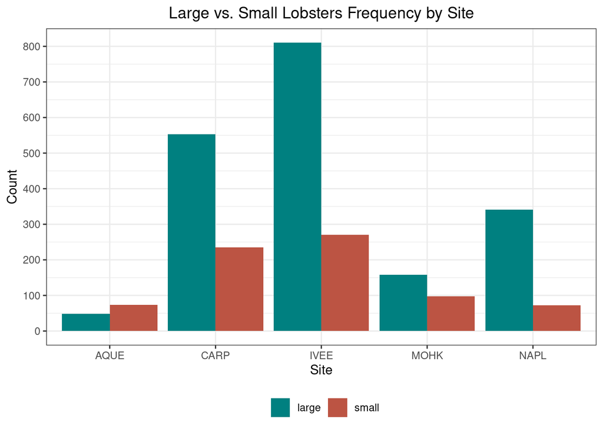

```r
lobster_size_lrg <- lobster_abundance %>%
  filter(YEAR %in% c(2019, 2020, 2021)) %>%
  mutate(SIZE_BIN = if_else(SIZE_MM <= 70, true = "small", false = "large")) %>%
  group_by(SITE, SIZE_BIN) %>%
  summarize(COUNT = n()) %>%
  drop_na()
ggplot(data = lobster_size_lrg,
       aes(x = SITE, y = COUNT,
           fill = SIZE_BIN)) +
  geom_col(position = "dodge") +
  theme_bw()+
  xlab("Site")+
  ylab("Count")+
  ggtitle("Large vs. Small Lobsters Frequency by Site") +
  theme(plot.title = element_text(hjust = 0.5),
         legend.position = "bottom",
        legend.title = element_blank())+
  scale_y_continuous(breaks = seq(0, 800, 100)) +
scale_fill_manual(values = c("#008080", "#BC5443"))
```

## Exercise: Explore, Clean, and Wrangle Data

## Working Data

```r
lobster_traps <- read_csv("data/Lobster_Trap_Counts_All_Years_20210519.csv")
```

Convert missing values

```r
clean_lobster_traps <- lobster_traps %>%
 mutate(TRAPS = na_if(TRAPS, -99999))
```

## Plotting data

Playing with Themes and visualizations

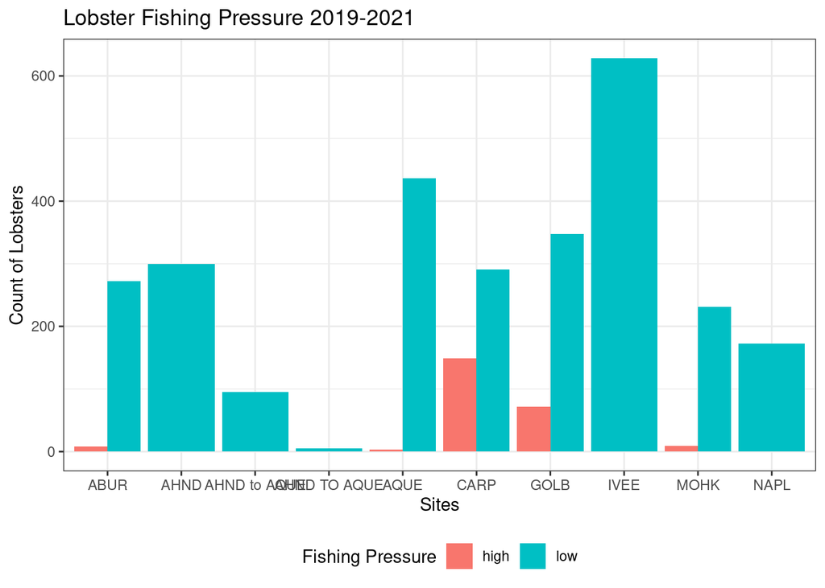

```r
lobster_traps_fishing_pressure <- lobster_traps %>%
    filter(YEAR %in% c(2019, 2020, 2021)) %>%
    mutate(FISHING_PRESSURE = if_else(TRAPS >= 8, true = "high", false = "low")) %>%
    group_by(SITE, FISHING_PRESSURE) %>%
    summarize(COUNT = n()) %>%
    drop_na()

ggplot(data = lobster_traps_fishing_pressure, aes(x = SITE, y = COUNT, fill = FISHING_PRESSURE)) +
    geom_col(position = "dodge")+
  theme_bw()+
  labs(
    title = "Lobster Fishing Pressure 2019-2021",
    x = "Sites",
    y = "Count of Lobsters",
    fill = "Fishing Pressure") +
  theme(legend.position = "bottom")
```